# PADP8120 Homework 5

Thomas K. Valentine

December 2, 2015

# Problems

## Problem 1.

### Just as you did for Homework 4, write a function that emulates the `lm` function in R for a simple (bivariate) regression. *However, this time your function needs to make use of the matrix regression approach we learned in Week 12.* Like the `lm` function, your function should be able to estimate and report to the screen $\beta_k$ coefficients, standard errors for these coefficients, and corresponding t-values and p-values. It should also report the residual standard error. Be sure to show your code. Compare your results to the results of the `lm` function on some data of your choosing to verify that things are working correctly.

```r
x1 = rnorm(100)
x2 = rnorm(100)
y = matrix(rnorm(100),ncol=1)

#First, we create the matrix.
x.vars = as.matrix(data.frame(intercept = 1,x1,x2))

#Then we estimate for coefficients.
matrix.lm = function(outcome.matrix,design.matrix)
{
betas = solve(t(design.matrix) %*% design.matrix) %*% t(design.matrix) %*% outcome.matrix
betas = round(betas,3)

#Then, we estimate sigma-squared.
dSigmaSq <- sum((outcome.matrix - design.matrix%*%betas)^2)/(nrow(design.matrix)-ncol(design.matrix))

#We explore the variance covariance matrix
VarCovar <- dSigmaSq*chol2inv(chol(t(design.matrix)%*%design.matrix))

#and the coefficient of estimated standard errors
vStdErr <- round(sqrt(diag(VarCovar)),3)

#We then establish the degrees of freedom and observe the t-score
df = nrow(outcome.matrix) - length(betas)
t.obs = round(betas/vStdErr,3)
p.vals = round(2 * (1-pt(abs(t.obs),df=df)),3)
return(data.frame(coefs = betas,SE = vStdErr,
                  t.obs = t.obs,p.vals=p.vals))}

matrix.lm(y,x.vars)
```

```
##            coefs    SE  t.obs p.vals
## intercept  0.077 0.094  0.819  0.415
## x1        -0.094 0.093 -1.011  0.315
## x2        -0.185 0.092 -2.011  0.047
```

```r
summary(lm(y~x1+x2))
```

```
##
## Call:
## lm(formula = y ~ x1 + x2)
##
## Residuals:
##      Min       1Q   Median       3Q      Max
## -2.10361 -0.59970 -0.07786  0.59223  2.81640
##
## Coefficients:
##             Estimate Std. Error t value Pr(>|t|)
## (Intercept)  0.07707    0.09357   0.824   0.4122
## x1          -0.09352    0.09343  -1.001   0.3193
## x2          -0.18535    0.09248  -2.004   0.0478 *
## ---
## Signif. codes:  0 '***' 0.001 '**' 0.01 '*' 0.05 '.' 0.1 ' ' 1
##
## Residual standard error: 0.9333 on 97 degrees of freedom
## Multiple R-squared:  0.04669,    Adjusted R-squared:  0.02703
## F-statistic: 2.375 on 2 and 97 DF,  p-value: 0.09838
```

## Problem 2: Occupational prestige

### Let’s try to understand the relationship between typical education, income, job type, and occupation prestigue using the data from Duncan. You can read the documentation [here](http://socserv.socsci.mcmaster.ca/jfox/Books/Applied-Regression-2E/datasets/Duncan.pdf)

### Here’s some code to read in and clean the data. And for the purposes of this assignment we are going to exclude professionals. In other words, we are only concerned about white collar and blue collar occupations. Again, notice that the unit here is occupations.

```r
library(dplyr)
#We create a new clean data set: occpn
occpn <- read.table("input/Duncan.txt", header=TRUE)
occpn$state <- rownames(occpn)
rownames(occpn) <- NULL
occpn <- filter(occpn, type %in% c("wc", "bc"))
head(occpn)
```

```
##   type income education prestige           state
## 1   wc     67        87       52        reporter
## 2   wc     76        34       38       conductor
## 3   wc     29        72       39      bookkeeper
## 4   wc     48        55       34    mail.carrier
## 5   wc     55        71       41 insurance.agent
## 6   wc     29        50       16     store.clerk
```

### (a) Run a regression model to predict the prestige of an occupation based on the level of education of people in that occupation (measured by the percentage of people in the field who have graduated from high school in 1950).

```r
summary(mod1 <- lm(prestige~education,occpn))
```

```
##
## Call:
## lm(formula = prestige ~ education, data = occpn)
##
## Residuals:
##     Min      1Q  Median      3Q     Max
## -18.235 -11.137  -2.905   6.383  43.725
##
## Coefficients:
##             Estimate Std. Error t value Pr(>|t|)
## (Intercept)   9.8423     6.1155   1.609  0.12008
## education     0.4798     0.1601   2.996  0.00609 **
## ---
## Signif. codes:  0 '***' 0.001 '**' 0.01 '*' 0.05 '.' 0.1 ' ' 1
##
## Residual standard error: 15.46 on 25 degrees of freedom
## Multiple R-squared:  0.2642, Adjusted R-squared:  0.2348
## F-statistic: 8.977 on 1 and 25 DF,  p-value: 0.006093
```

### (b) Make a plot showing the data and the model that you fit.

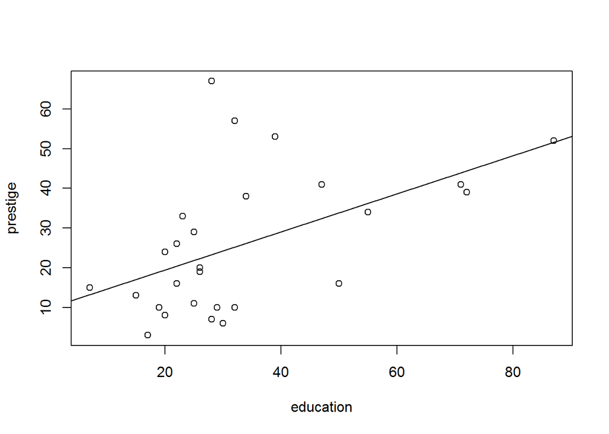

```r
plot(prestige~education,data=occpn)
abline(reg = mod1)
```

### (c) Now run a regression model to predict the prestige of an occupation based on the level of education of people in that occupation (measured by the percentage of people in the field who have graduated from high school in 1950) and the occupation type (blue collar/white collar).

```r
summary(mod2 <- lm(prestige~education+type,data=occpn))
```

```
##
## Call:
## lm(formula = prestige ~ education + type, data = occpn)
##
## Residuals:
##     Min      1Q  Median      3Q     Max
## -19.845 -11.390  -2.934   5.101  42.476
##
## Coefficients:
##             Estimate Std. Error t value Pr(>|t|)
## (Intercept)   6.0236     7.7386   0.778   0.4439
## education     0.6607     0.2745   2.407   0.0241 *
## typewc       -9.9913    12.2656  -0.815   0.4233
## ---
## Signif. codes:  0 '***' 0.001 '**' 0.01 '*' 0.05 '.' 0.1 ' ' 1
##
## Residual standard error: 15.56 on 24 degrees of freedom
## Multiple R-squared:  0.284,  Adjusted R-squared:  0.2243
## F-statistic:  4.76 on 2 and 24 DF,  p-value: 0.01815
```

### (d) Make a plot showing the data and the model that you fit.

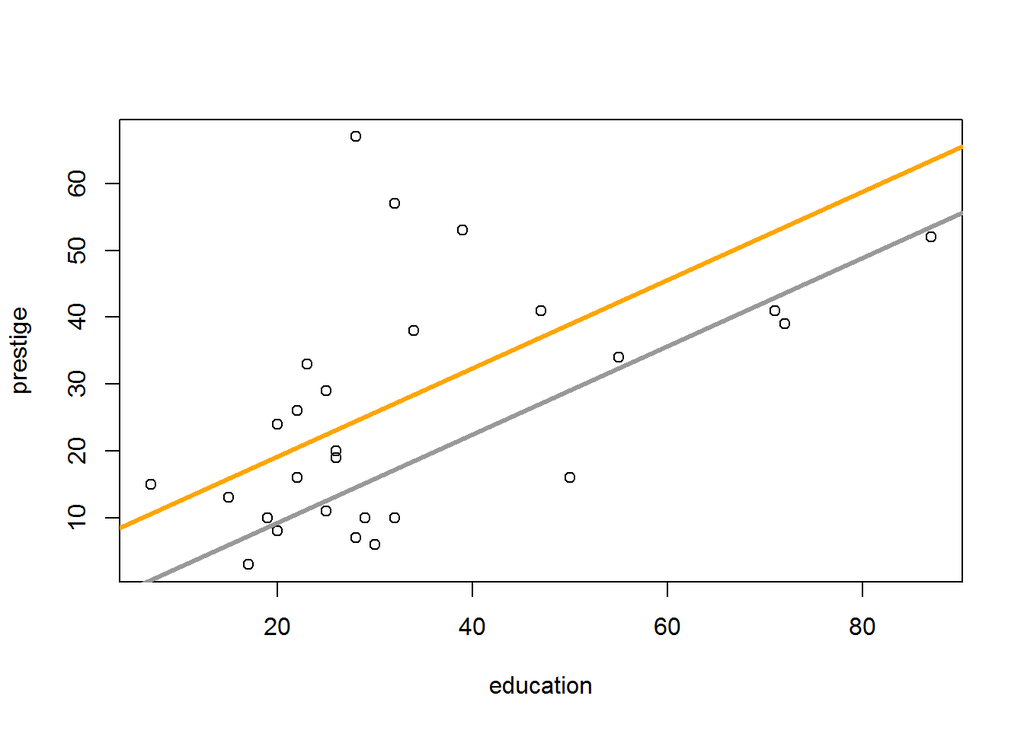

```r
plot(prestige~education,data=occpn)
abline(a=mod2$coef[1],b=mod2$coef[2],col='orange',lwd=3)
abline(a=mod2$coef[1]+mod2$coef[3],b=mod2$coef[2],col='grey60',lwd=3)
```

### (e) Now run a regression model to predict occupational prestige based on the level of education and occupation type where the relationship between education and occupational prestige is allowed to vary by occupation type.

```r
summary(mod3 <- lm(prestige~education*type,data=occpn))
```

```
##
## Call:
## lm(formula = prestige ~ education * type, data = occpn)
##
## Residuals:
##     Min      1Q  Median      3Q     Max
## -21.481 -10.352  -1.645   6.620  41.542
##
## Coefficients:
##                  Estimate Std. Error t value Pr(>|t|)
## (Intercept)       -2.8544    10.8807  -0.262   0.7954
## education          1.0112     0.4083   2.476   0.0211 *
## typewc            16.2190    25.7952   0.629   0.5357
## education:typewc  -0.6323     0.5485  -1.153   0.2609
## ---
## Signif. codes:  0 '***' 0.001 '**' 0.01 '*' 0.05 '.' 0.1 ' ' 1
##
## Residual standard error: 15.46 on 23 degrees of freedom
## Multiple R-squared:  0.3231, Adjusted R-squared:  0.2348
## F-statistic:  3.66 on 3 and 23 DF,  p-value: 0.02722
```

### (f) Calculate predicted levels of prestige for white collar and blue collar jobs at various levels of income and report these predicted levels in a graph (no table needed). What have you learned about prestige thanks to the interactive variable?

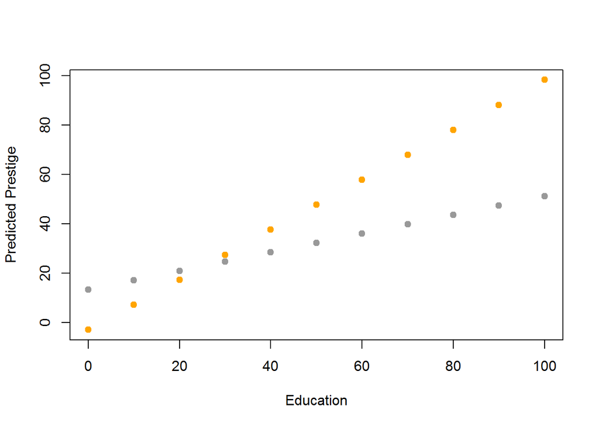

```r
pred.vals = predict(mod3,newdata = data.frame(
  education=rep(seq(0,100,10),2),type=rep(c('wc','bc'),each=11)))

plot(x=rep(seq(0,100,10),2),y=pred.vals,col=rep(c('grey60','orange'),each=11),pch=19,xlab='Education',ylab='Predicted Prestige')
```

### (g) How would you summarize the conclusions from three models above?

- White collar workers who experience a 1 percent increase in education receive a .38 increase in occup. prestige, as opposed to the more dramatic 1.01 increase in occup prestige that a blue collar worker earns for the same 1 degree increse in education.
- There is a positive correlation between education level and occupational prestige for both type of workers.
- Each type of job has a seperate intercept, which indicates a different starting point in expected education for white and blue collar workers.
- Model 1, which maps occup. prestige against education, fits best

```r
library(car)
anova(mod1,mod2,mod3)
```

```
## Analysis of Variance Table
##
## Model 1: prestige ~ education
## Model 2: prestige ~ education + type
## Model 3: prestige ~ education * type
##   Res.Df    RSS Df Sum of Sq      F Pr(>F)
## 1     25 5972.7
## 2     24 5812.0  1    160.69 0.6726 0.4206
## 3     23 5494.5  1    317.45 1.3288 0.2609
```

```r
tapply(occpn$education,occpn$type,mean)
```

```
##       bc     prof       wc
## 25.33333       NA 61.50000
```

### (h) Now run a the following regression model: `lm(prestige ∼ income + education + income ∗ education)` and substantively describe the effects of the independent variables on the dependent variable. In other words, describe the relationships implied by the interactive terms. Does this interaction make sense to you? Why or why not? No table needed.

```r
summary(mod4 <- lm(prestige ~income+ education + income * education,occpn))
```

```
##
## Call:
## lm(formula = prestige ~ income + education + income * education,
##     data = occpn)
##
## Residuals:
##     Min      1Q  Median      3Q     Max
## -17.218  -6.319  -1.414   6.584  26.711
##
## Coefficients:
##                   Estimate Std. Error t value Pr(>|t|)
## (Intercept)      -0.386045   8.061381  -0.048  0.96222
## income            0.737786   0.212345   3.474  0.00205 **
## education         0.256704   0.285466   0.899  0.37784
## income:education -0.003559   0.005823  -0.611  0.54711
## ---
## Signif. codes:  0 '***' 0.001 '**' 0.01 '*' 0.05 '.' 0.1 ' ' 1
##
## Residual standard error: 10.62 on 23 degrees of freedom
## Multiple R-squared:  0.6807, Adjusted R-squared:  0.639
## F-statistic: 16.34 on 3 and 23 DF,  p-value: 6.597e-06
```

#### Model 4 (a regression of occup. prestige on income, ed. level, interaction between income and ed. level) tells us the following:

```r
testmod = lm(prestige~income+education,occpn)
anova(testmod,mod4)
```

```
## Analysis of Variance Table
##
## Model 1: prestige ~ income + education
## Model 2: prestige ~ income + education + income * education
##   Res.Df    RSS Df Sum of Sq      F Pr(>F)
## 1     24 2634.0
## 2     23 2591.9  1    42.087 0.3735 0.5471
```

### (i) Use calculus to identify the predicted impact of a one unit change in income on occupational prestige. Assess whether this impact is statistically distinct from zero. Remember that the variance for an estimated marginal effect $\frac{\partial \hat{y}}{\partial x} = \hat{\beta}_x + \hat{\beta}_{xz}*z$ where x and z are interacted independent variables, can be calculated by:

$V(\frac{\partial \hat{y}}{\partial x}) = V(\hat{\beta}_x) + z^2 V(\hat{\beta}_{xz}) + 2z * Cov(\hat{\beta}_x,\hat{\beta}_{xz})$

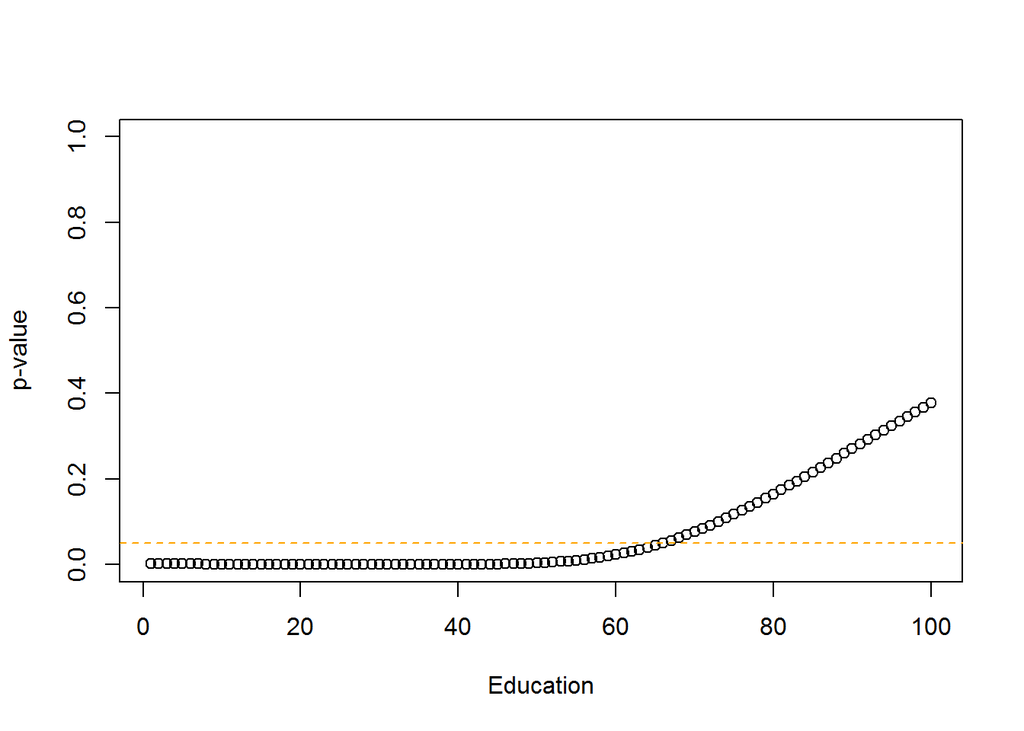

```r
#First, we calculate marginal effect for educational levels (educ = 1 to 100)
educ = seq(1:100)
beta_x = mod4$coef[2]
beta_xz = mod4$coef[4]
inc.slopes = beta_x + beta_xz * educ

#Second, we calculate variance for the interaction term
var.beta_x = vcov(mod4)[2,2]
var.beta_xz = vcov(mod4)[4,4]
cov.beta_x.beta_xz = vcov(mod4)[4,2]
var.dy.dx = var.beta_x + educ^2 * var.beta_xz + 2*educ*cov.beta_x.beta_xz

p.vals = 2 * (1-pt(abs(inc.slopes/sqrt(var.dy.dx)),df=nrow(occpn)-length(mod4)))
plot(p.vals~educ,ylim=c(0,1),ylab='p-value',xlab='Education')
abline(h=0.05,col='orange',lty=2)
```

### (j) ￼Because the marginal effect of x depends on values of z, you will need to assess whether the marginal effect is significant across a range of values of z.

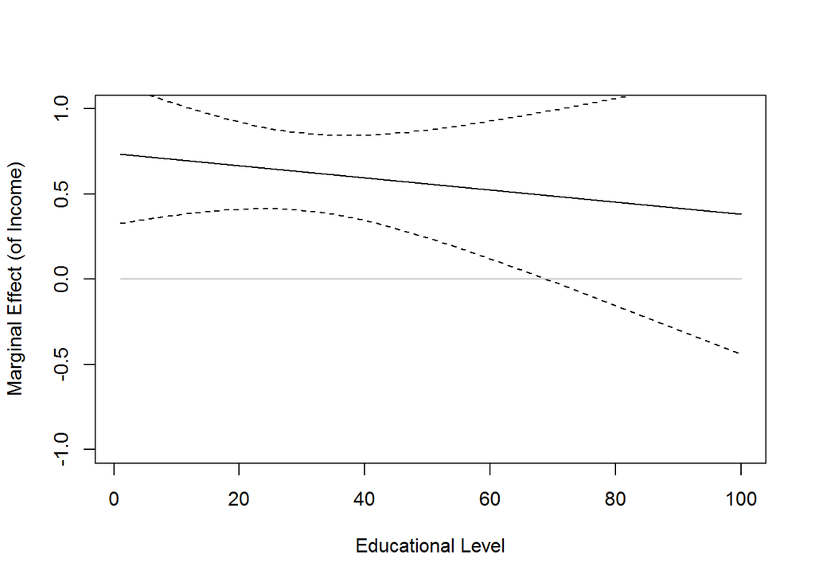

```r
upper <- inc.slopes + 1.96*sqrt(var.dy.dx)
lower <- inc.slopes - 1.96*sqrt(var.dy.dx)
plot(educ, inc.slopes , type = "l", lty = 1, xlab = "Educational Level", ylab = "Marginal Effect (of Income)",ylim=c(-1,1))
points(educ, upper, type = "l", lty = 2)
points(educ, lower, type = "l", lty = 2)
points(educ, rep(0, length(educ)), type = "l", col = "gray")
```

When we look at educational levels below 60, the 95% confidence interval doesn’t include 0, confirming the findings from part i.

## Problem 3: LA Housing Prices

### Load the LA housing prices dataset:

```r
la.dat = read.csv('Input/LA.csv')
```

### (a) Fit the best model you can to predict housing prices in LA on the basis of theory (i.e., what should matter for house prices?) and model fit (i.e., DO NOT use stepwise regression, but feel free to add/subtract/transform variables as you feel are necessary).

#### We will operate on the theory that house prices are conditional on the following variables:

- size